# STAT5003

Week 1: Basics of statistical computing and visualization

Jaslene Lin

## Basics of Statistical Computing

- Review basic statistical concepts
- Introduction to R
- Reproducible coding using Rmarkdown
- Recommended IDE via RStudio

# Review of basic statistical concepts

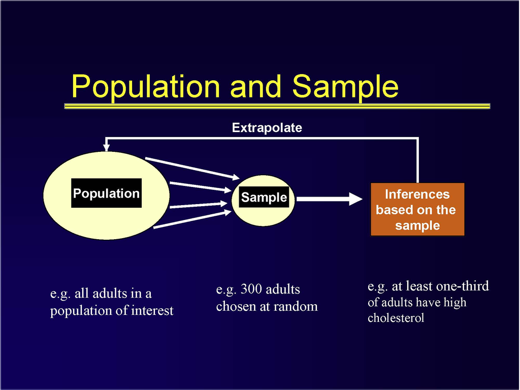

## Population

- **Definition**:
  - The set of data (numeric or otherwise) corresponding to the entire collection of units about which information is sought.
- **Examples**:
  - Cholesterol levels– Cholesterol levels of ALL adults in Australia.
  - The number of languages spoken from ALL currently enrolled students in University of Sydney.

## Sample

- **Definition:**
  - A subset of the population data that are actually collected in the course of a study.
- **Examples**:
  - Cholesterol levels of 300 adults chosen at random in Australia.
  - The number of languages spoken from 500 randomly selected students currently enrolled in University of Sydney.

> In most studies, it is difficult to obtain information about the whole population. That is why we rely on samples to make estimates and inferences related to the whole population.

## Parameters vs Statistics

- A **parameter** is a number that describes a population.
  - Notation usually denoted with Greek letters, e.g. $\mu$, $\sigma$.
- A **statistic** is a number that describes a sample.
  - Sample statistics are usually denoted using Roman letters, e.g. $x$, $s$.
- A parameter is a fixed number (usually unknown).
- A statistic is a variable whose value varies from sample to sample.

## Quiz

You are conducting a survey to understand **the study habits your peers in STAT5003**. The survey includes questions about the time spent studying, preferred study methods, and familiarity with basic statistical concepts.

In the context of your survey, what is the definition of a population?

✗A subset of students who responded to the survey

✓All students in STAT5003

✗A numerical summary of the survey responses

✗A graphical representation of the survey data

## Quiz

In your survey, what is a sample?

✗All students in STAT5003

✓A subset of students who responded to the survey

✗A numerical summary of the survey responses

✗A graphical representation of the survey data

## Quiz

In your survey, the number of hours students study per week is **likely** an example of what type of data?

✓Continuous

✓Discrete

✗Categorical

✗Ordinal

## Descriptive statistics – numeric and graphics

Many methods are available for summarising data in both **numeric** and **graphical** form

Numeric measures:

- Measure of location
  - Mean, Median, Mode for numeric data
  - Counts, proportions for categorical data
- Measure of spread
  - Standard deviation, MAD (median absolute deviation), IQR (interquartile range)
- Others
  - Min, Max, Quartile, Five number summaries (used later in boxplot)

# Basic statistical graphics

## Types of graphics covered in this course

- Become familiar with simple graphics using base**R** and ggplot graphics
- base**R** use the built in plotting functions
  - Typically good for quick plots of simple datasets
- ggplot graphics
  - Name meaning the grammar of graphics
  - Typically better for more complicated datasets

## Simple example dataframe for plots

```r
set.seed(5003)

example.dat <- data.frame(x = rnorm(100),
                          y = runif(100),
                          cat = sample(LETTERS[1:2], prob = c(1, 3), size = 100, replace = TRUE))
head(example.dat)
```

```
            x         y cat
1 -0.08569102 0.6601036   B
2  0.12462451 0.4534993   B
3  0.87579853 0.4029725   B
4  0.77128325 0.9148725   B
5 -0.29414040 0.1930455   A
6 -0.64272686 0.5727217   B
```

```r
library(tidyverse)
```

## Single numeric variable: Boxplot in base**R**

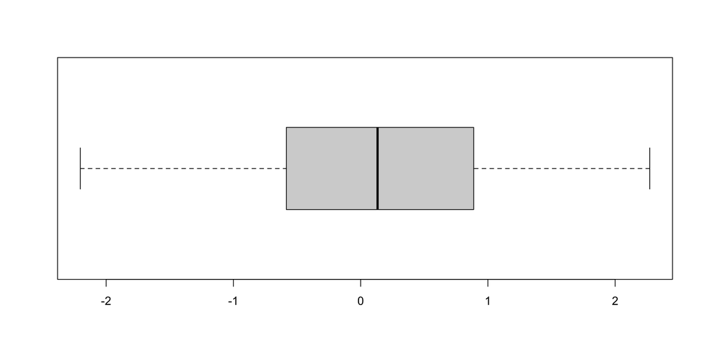

```r
boxplot(example.dat$x, horizontal = TRUE)
```

## Single numeric variable: Boxplot in ggplot

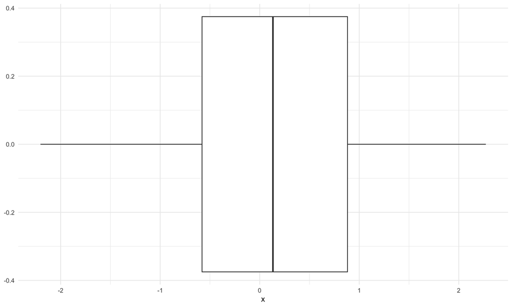

```r
library(ggplot2) # Only need to load the library once in an R session
ggplot(example.dat, aes(x = x)) + geom_boxplot() + theme_minimal()
```

## Single numeric variable: Histogram in base**R**

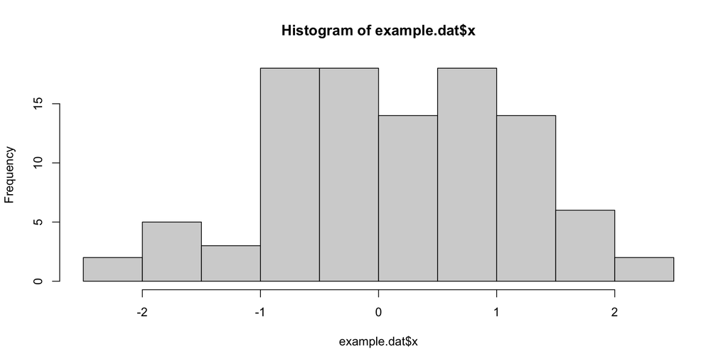

```r
hist(example.dat$x)
```

## Single numeric variable: Histogram in ggplot

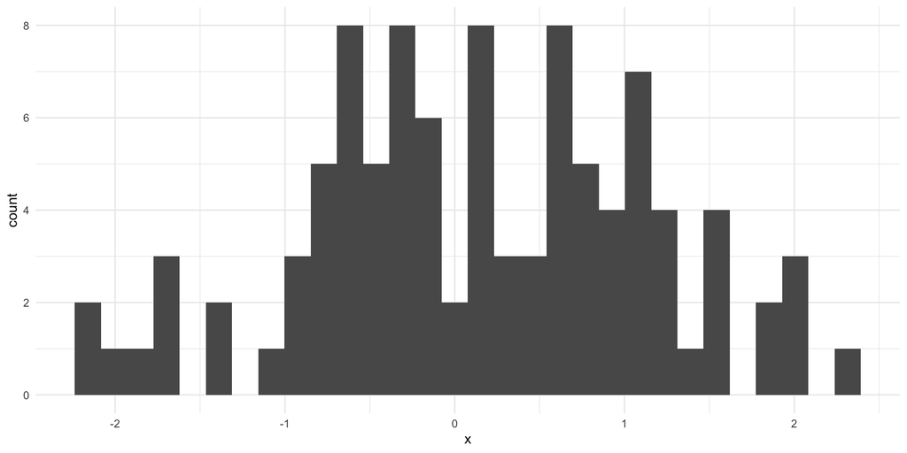

```r
ggplot(example.dat, aes(x = x)) + geom_histogram() + theme_minimal()
```

## Single categorical variable: Bar plot in base **R**

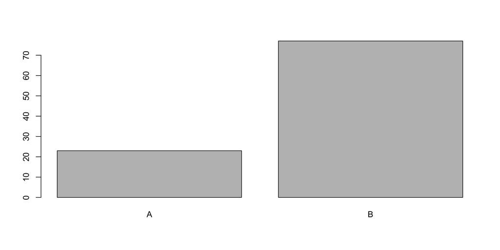

```r
barplot(table(example.dat$cat))
```

## Single categorical variable: Bar plot in ggplot

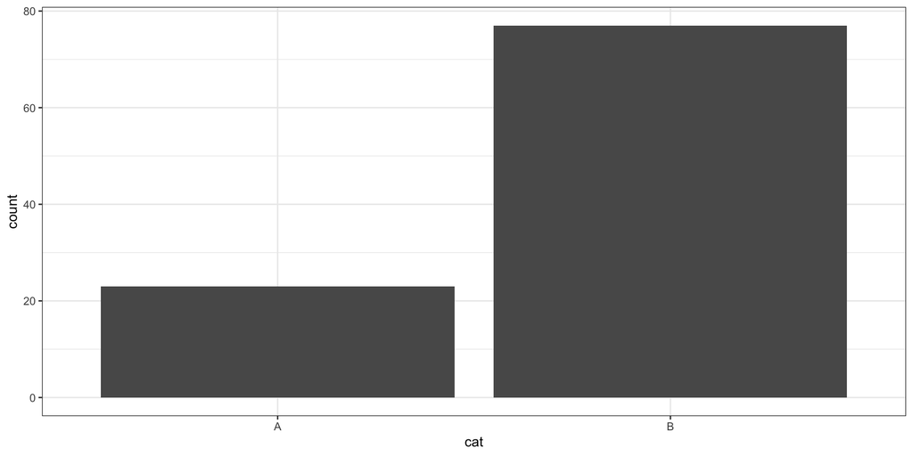

```r
ggplot(example.dat, aes(x = cat)) + geom_bar() + theme_bw() # Change the theme
```

## Two numeric variables: Scatterplot in base **R**

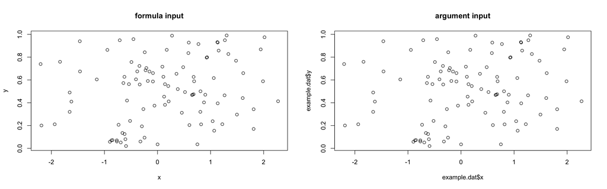

```r
# These two plot commands are near equivalent
plot(y ~ x, data = example.dat, main = "formula input")
plot(example.dat$x, example.dat$y, main = "argument input")
```

## Two numeric variables: Scatterplot in ggplot

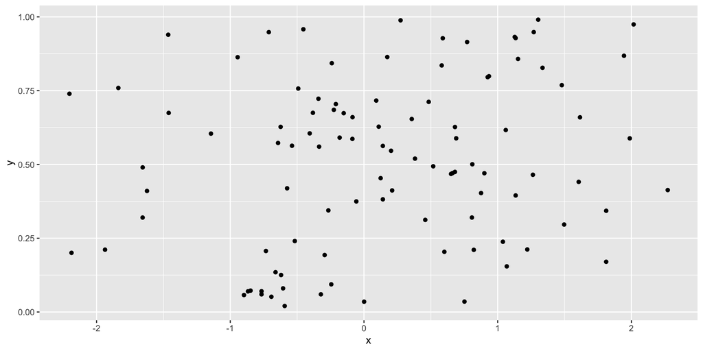

```r
ggplot(example.dat, aes(x = x, y = y)) + geom_point() # default theme here
```

## Quiz

What is the purpose of a histogram in the context of your survey data?

✗To show the relationship between two variables

✓To display the frequency distribution of study hours

✗To summarize the central tendency of study hours

✗To compare the means of different study methods

## What is **R**?

- Free, open source software designed for statistical computing
- Runs on Windows, Mac, Linux, and other flavours of Unix
- Provides an interactive environment, but it is also an interpreted programming language
- Its power lies in the thousands of contributed packages on CRAN, Bioconductor, and github

## What is RStudio?

- RStudio is an integrated development environment (IDE) for **R**
- Think of it as the front-end, like a powerful text editor
- R needs to be installed first before RStudio


## Base **R** versus **Tidyverse**

- Core Base **R**
  - Syntax and Functions: Good for production level code, stable but function syntax inconsistent.
  - Data Manipulation: using functions like `apply()`, `lapply()`, `sapply()`, and `tapply(),` which can be powerful but sometimes complex and less readable.
  - Data Visualization: Base R provides basic plotting functions such as `plot()`, `hist()`, and `boxplot()`.
- **Tidyverse**
  - Has a (somewhat) standardised syntax. Pipes (base `|>` and the magrittr `%>%`) are king except for `+` in `ggplot2`
  - Produces more human readable code
  - Not as stable as base, breaking changes occur as `tidyverse` develops
  - Good for interactive data analyst

## **R** Session

- **Working Directory**: Each session runs from a working directory
  - `getwd()` shows the current working directory for R
  - `setwd(<path>)` to change the working directory where `<path>` is a string
    - Example: `setwd("C:/Users/usyd-student")` for a windows user
- **Workspace**: Includes
  - Global environment: Data and variables loaded or defined
  - package environments: Any loaded packages with their functions/data
- **History**:
  - Can view your recent commands in the History pane
  - Can navigate previous commands using up and down arrows at your prompt

## Packages

- Inspect the current environment
  - `sessionInfo()`: shows everything in the current R session
- To install a new package
  - `install.packages("cluster")` will install the `cluster` package from the Comprehensive R Archive Network (CRAN) repository
- To load a package to use in the environment `library(cluster)`
  - After loading a package, you will be able to use the functions provided in that package
- If name conflicts arise you can specify the desired function using `::`
  - Example: `dplyr::filter` will use the `filter` function from the `dplyr` package instead of the `stats::filter` function

## Help

- CRAN requires every exported function in every contributed package to have a help file
  - `help.start()`
  - `help(plot)`
  - `? plot`
- In general, the help file for each function gives a brief description of what the function does, the required inputs, the expected outputs and some examples
  - Some packages also include a “vignette”, a short document with guidance on using the package

## Quirks of R syntax

- `<-` is the symbol for ‘assign’, e.g. `x <- 14`
  - equivalent to: `x = 14` when used at the prompt
- Should use `=` for argument matching in a function
- The period symbol `.` can be used in variable names
  - Example: `new.vector <- c("A", "B", "C")`
- Element indexing starts at 1

```r
    new.vector <- c("A", "B", "C")
    new.vector[0]
```

```
character(0)
```

```r
    new.vector[1]
```

```
[1] "A"
```

## Basic data types in R

- Factor : Categorical data type
  - Unique to R (integer with some attributes)

  ```r
  data("ToothGrowth")
  levels(ToothGrowth$supp)
  ```

  ```
  [1] "OJ" "VC"
  ```

  ```r
  class(ToothGrowth$supp)
  ```

  ```
  [1] "factor"
  ```

  ```r
  str(ToothGrowth$supp)
  ```

  ```
   Factor w/ 2 levels "OJ","VC": 2 2 2 2 2 2 2 2 2 2 ...
  ```

Classical data types

- Numeric
- Integer
- Logical
- Character
- Complex

## Homogeneous vs non-homogenous data types in R

### Homogeneous

- Vector
  - Sequence of data elements of the same basic data type
- Matrix
  - Collection of data elements in a 2-dimensional array with rows and columns

### Non-homogeneous

- List
  - More general structure containing other objects (including possibly other lists)
- Data frame
  - Used for storing data, each column can be a different basic type
  - All columns must have the same length

## Vectors

```r
new.vector <- c(1, 2, 3)
class(new.vector)
```

```
[1] "numeric"
```

```r
length(new.vector)
```

```
[1] 3
```

```r
new.vector[1:2]
```

```
[1] 1 2
```

```r
new.vector <- c(1, 2, "hello")
class(new.vector)
```

```
[1] "character"
```

```r
is.vector(new.vector)
```

```
[1] TRUE
```

## Matrix

```r
A <- matrix(c(2, 4, 3, 1, 7, 8), nrow = 3)
# Unless specified otherwise, it will fill the matrix by column.
A
```

```
     [,1] [,2]
[1,]    2    1
[2,]    4    7
[3,]    3    8
```

```r
A[2, 1]
```

```
[1] 4
```

```r
A[1, ]
```

```
[1] 2 1
```

```r
A[5]
```

```
[1] 7
```

## List

```r
vector.a <- c(1, 2, 3)
vector.b <- c("hello", "world", "!!")
new.list <- list(c(vector.a, vector.b))
new.list
```

```
[[1]]
[1] "1"     "2"     "3"     "hello" "world" "!!"
```

```r
new.list <- list(vector.a, vector.b)
new.list
```

```
[[1]]
[1] 1 2 3

[[2]]
[1] "hello" "world" "!!"
```

```r
new.list[[1]]
```

```
[1] 1 2 3
```

## Data frames

```r
head(warpbreaks)
```

```
  breaks wool tension
1     26    A       L
2     30    A       L
3     54    A       L
4     25    A       L
5     70    A       L
6     52    A       L
```

```r
str(warpbreaks)
```

```
'data.frame':   54 obs. of  3 variables:
 $ breaks : num  26 30 54 25 70 52 51 26 67 18 ...
 $ wool   : Factor w/ 2 levels "A","B": 1 1 1 1 1 1 1 1 1 1 ...
 $ tension: Factor w/ 3 levels "L","M","H": 1 1 1 1 1 1 1 1 1 2 ...
```

```r
names(warpbreaks)
```

```
[1] "breaks"  "wool"    "tension"
```

```r
class(warpbreaks)
```

```
[1] "data.frame"
```

```r
head(warpbreaks$wool)
```

```
[1] A A A A A A
Levels: A B
```

## Rprojects

- Each Rstudio project has its own working R session, workspace, history, and source documents
- You can either create an Rproject in a new directory or within and existing directory
- When you open an .Rproj file, the following happens:
  - A new R session (process) is started
  - If it exists, the .Rprofile in the project’s main directory is loaded
  - If applicable, the .RData file in the main directory is loaded
  - If set, the .Rhistory file in the main directory is loaded
  - The current working directory is set to the project directory
  - If set, previously edited documents appear in the source editor